# Case Study: Critics and Wine

## Meet Robert Parker

[figure not shown]

The most influential critic in the world today happens to be a critic of wine. His name is Robert Parker.

## Meet Clive Coates

[figure not shown]

Clive Coates, Master of Wine, is one of the world's leading wine authorities.

Parker is the wine writer who matters. Clives Coates is very serious and well-respected, but in terms of commercial impact his influence is zero.

## The data

```r
wine <- read.csv("http://andrewpbray.github.io/data/Bordeaux.csv")
dim(wine)
```

```
## [1] 72  9
```

```r
names(wine)
```

```
## [1] "Wine"             "Price"            "ParkerPoints"
## [4] "CoatesPoints"     "P95andAbove"      "FirstGrowth"
## [7] "CultWine"         "Pomerol"          "VintageSuperstar"
```

## The mission

Develop a regression model to estimate the percentage effect on price of a 1% increase in ParkerPoints and a 1% increase in CoatesPoins using a subset of or all seven predictors.

## Exploratory Data Analysis

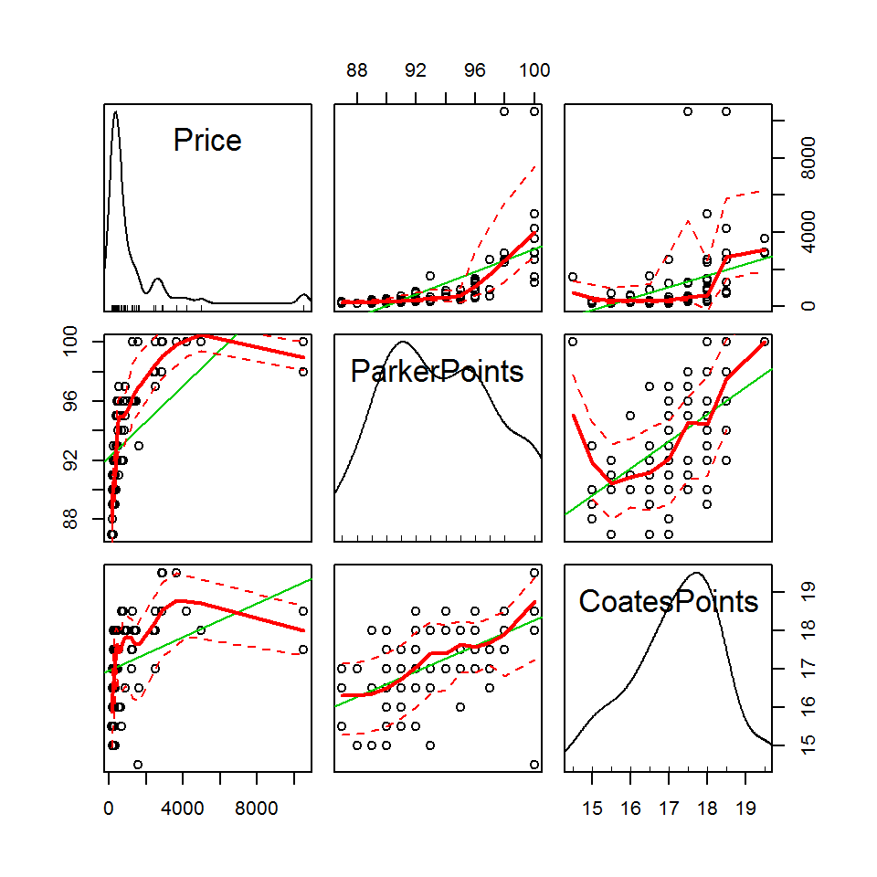

```r
library(car)
scatterplotMatrix(wine[, 2:4])
```

## EDA

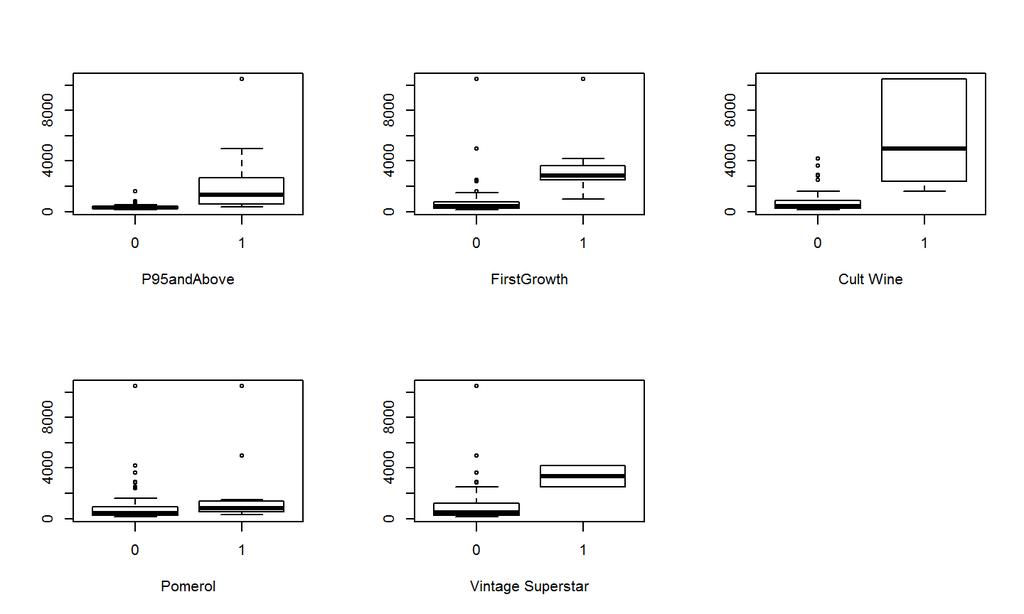

## Fitting the simplest model.

\[ \widehat{Price} \sim ParkerPoints + CoatesPoints + P95andAbove \\+ FirstGrowth + CultWine + Pomerol + VintageSuperstar \]

```r
m1 <- lm(Price ~ . - Wine, data = wine)
```

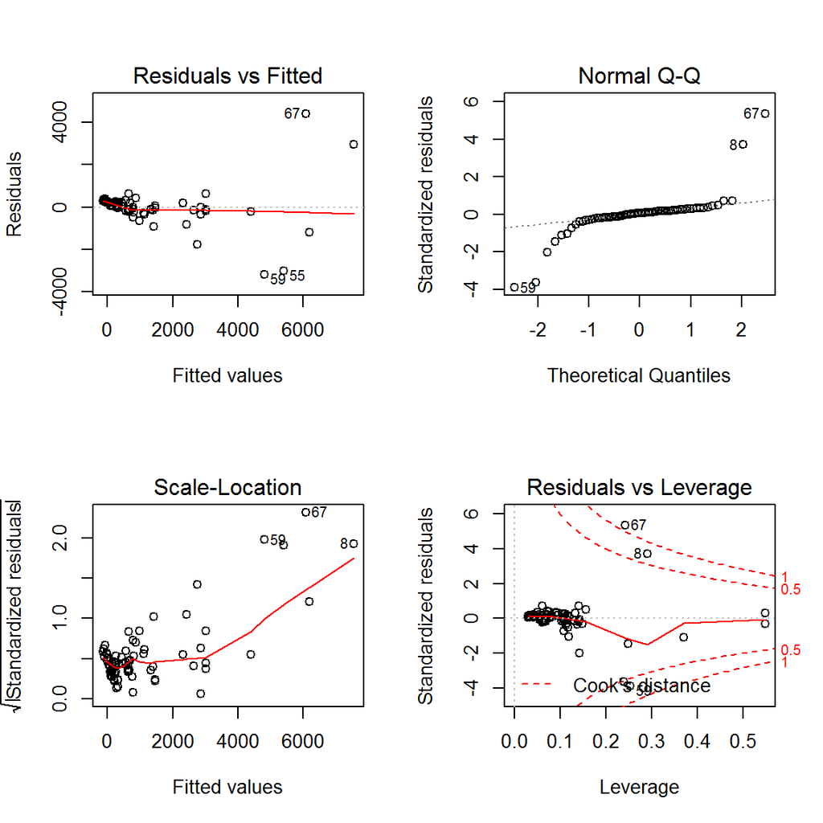

## \(Y\) versus \(\hat{Y}\)

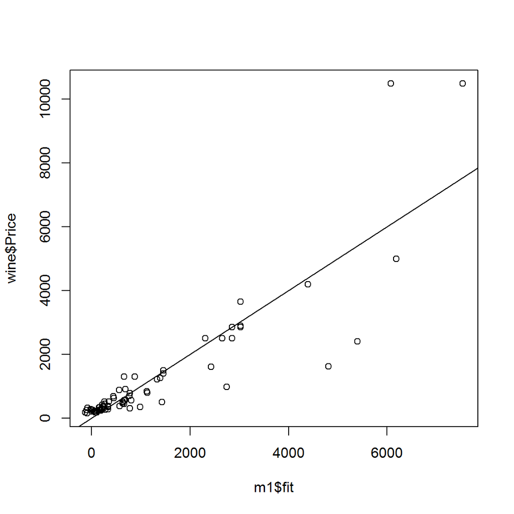

```r
plot(wine$Price ~ m1$fit, data = wine)
abline(0, 1)
```

## A second model

```r
wine <- transform(wine, logPrice = log(Price),
                  logParkerPoints = log(ParkerPoints),
                  logCoatesPoints = log(CoatesPoints))
m2 <- lm(logPrice ~ . - Price - Wine - ParkerPoints - CoatesPoints,
         data = wine)
```

**Recall**: logging the predictors of interest as well as the response allows us to interpret the estimates slopes as the percentage increase in the \(Y\) associated with a 1% increase in the \(x\).

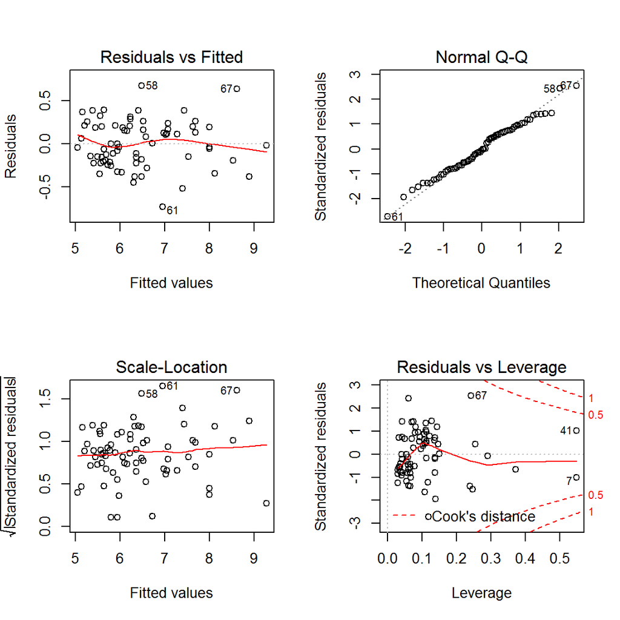

## MLR standardized res plots

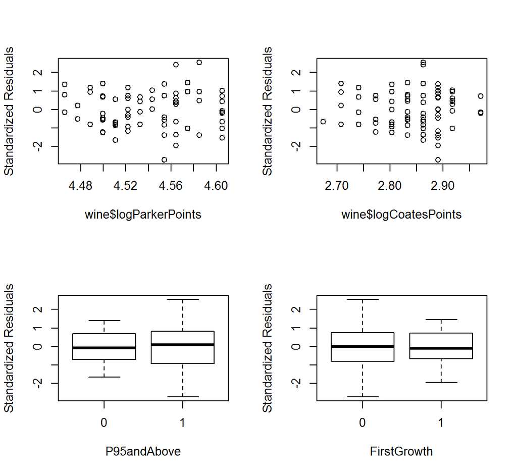

## MLR standardized res plots

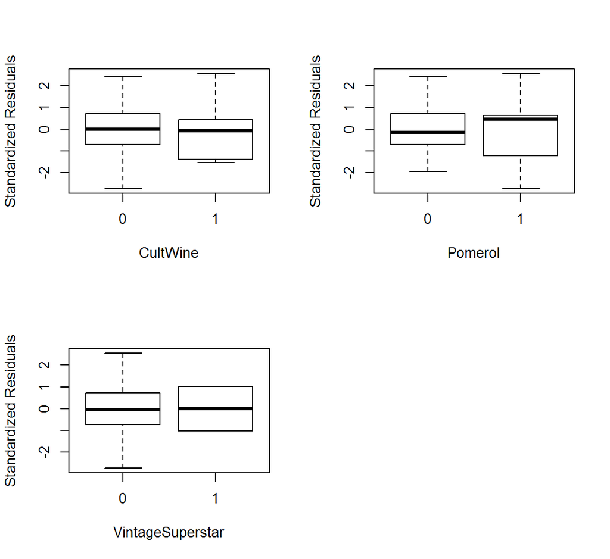

## \(Y\) versus \(\hat{Y}\)

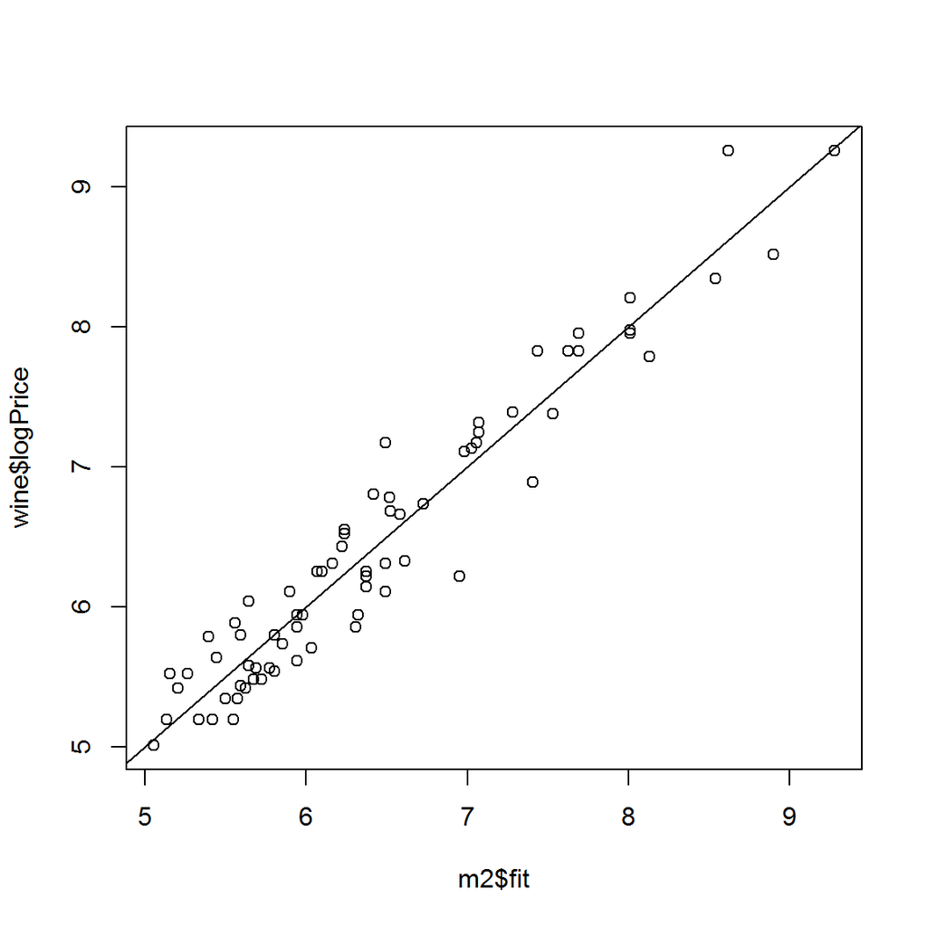

## MMPs

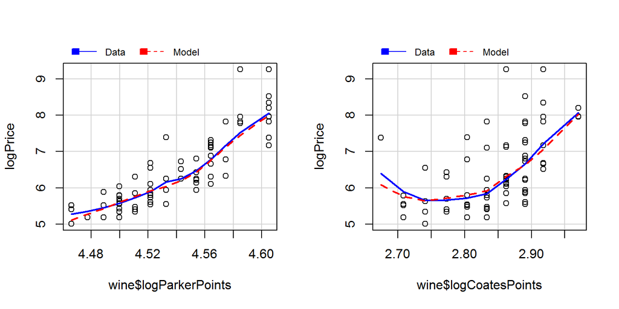

## AVPs

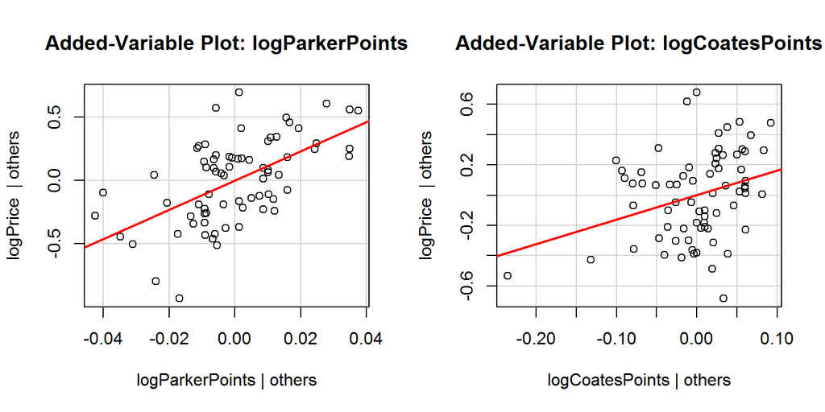

## Multicollinearity

```r
vif(m2)
```

```
##      P95andAbove      FirstGrowth         CultWine          Pomerol
##            4.013            1.625            1.188            1.124
## VintageSuperstar  logParkerPoints  logCoatesPoints
##            1.139            5.825            1.410
```

One value exceeds the traditional cutoff of 5, but not by too much. Multicollinearity is a minor issue here.

## Model validity

We're confident we're working with a valid model.

- **Linearity**: the conditional mean of the response is a linear function of the predictors. (See \(Y\) vs \(\hat{Y}\) and mmps)
- The errors have **constant variance** and are **uncorrelated**. (See standardized residual plots vs predictors)
- The errors are **normally distributed with mean zero**. (see QQ plot)

It's also sensible to build a model with:

- No highly influential points. (see Cook's dist plot)
- Low multicollinearity. (see VIF)

## Model summary

```
##                  Estimate Std. Error t value  Pr(>|t|)
## (Intercept)      -51.1416    8.98557 -5.6915 3.389e-07
## P95andAbove        0.1006    0.13697  0.7341 4.656e-01
## FirstGrowth        0.8697    0.12524  6.9441 2.332e-09
## CultWine           1.3532    0.14569  9.2878 1.784e-13
## Pomerol            0.5364    0.09366  5.7275 2.946e-07
## VintageSuperstar   0.6159    0.22067  2.7910 6.918e-03
## logParkerPoints   11.5886    2.06763  5.6048 4.744e-07
## logCoatesPoints    1.6205    0.61154  2.6499 1.013e-02
```

Note that all of the predictors are signficant at the .05 level (another reason to not worry too much about the borderline VIF), with the exception of `P95andAbove`.

We could consider dropping it from the model to remove redudancy with `logParkerPrice`.

## Updated model summary

```r
m3 <- update(m2, . ~ . - P95andAbove)
summary(m3)$coef
```

```
##                  Estimate Std. Error t value  Pr(>|t|)
## (Intercept)      -56.4755    5.26798 -10.721 5.205e-16
## FirstGrowth        0.8615    0.12430   6.931 2.299e-09
## CultWine           1.3360    0.14330   9.323 1.339e-13
## Pomerol            0.5362    0.09333   5.745 2.641e-07
## VintageSuperstar   0.5947    0.21800   2.728 8.186e-03
## logParkerPoints   12.7843    1.26915  10.073 6.662e-15
## logCoatesPoints    1.6045    0.60898   2.635 1.052e-02
```

Since the parameter estimates barely budged, this is essentially the same model as the previous one: no need to re-check diagnostic plots.